# Insurance Claims Rate Modelling with GLMs

Poisson and negative binomial GLMs for motor claim frequency (freMTPL2freq)

Saumya Shah

13 August 2026

# 1 Introduction

Motor insurers set premiums from a **claim frequency** model (how often a policy claims) and a **claim severity** model (how much each claim costs); this project covers frequency only. Frequency is naturally a *rate*: the expected number of claims a policy generates is proportional to how long it’s been on cover (its **exposure**, in policy-years), so the response is modelled with a Poisson or negative binomial GLM and `offset(log(Exposure))`, which is exactly the log-link rate-modelling setup for grouped/scaled count data.

```r
claims <- read.csv("data/freMTPL2freq_clean.csv", stringsAsFactors = TRUE)
str(claims)
```

```
## 'data.frame':    678013 obs. of  12 variables:
##  $ IDpol     : int  1 3 5 10 11 13 15 17 18 21 ...
##  $ ClaimNb   : int  1 1 1 1 1 1 1 1 1 1 ...
##  $ Exposure  : num  0.1 0.77 0.75 0.09 0.84 0.52 0.45 0.27 0.71 0.15 ...
##  $ Area      : Factor w/ 6 levels "A","B","C","D",..: 4 4 2 2 2 5 5 3 3 2 ...
##  $ VehPower  : int  5 5 6 7 7 6 6 7 7 7 ...
##  $ VehAge    : int  0 0 2 0 0 2 2 0 0 0 ...
##  $ DrivAge   : int  55 55 52 46 46 38 38 33 33 41 ...
##  $ BonusMalus: int  50 50 50 50 50 50 50 68 68 50 ...
##  $ VehBrand  : Factor w/ 11 levels "B1","B10","B11",..: 4 4 4 4 4 4 4 4 4 4 ...
##  $ VehGas    : Factor w/ 2 levels "Diesel","Regular": 2 2 1 1 1 2 2 1 1 1 ...
##  $ Density   : int  1217 1217 54 76 76 3003 3003 137 137 60 ...
##  $ Region    : Factor w/ 22 levels "R11","R21","R22",..: 18 18 3 15 15 8 8 20 20 12 ...
```

# 2 Exploratory data analysis

```r
claims %>%
  summarise(
    policies = n(),
    total_exposure = sum(Exposure),
    total_claims = sum(ClaimNb),
    overall_frequency = total_claims / total_exposure
  )
```

```
##   policies total_exposure total_claims overall_frequency
## 1   678013       358360.1        36056         0.1006139
```

The overall portfolio claim frequency (claims per policy-year) is the baseline against which rating factors are compared below.

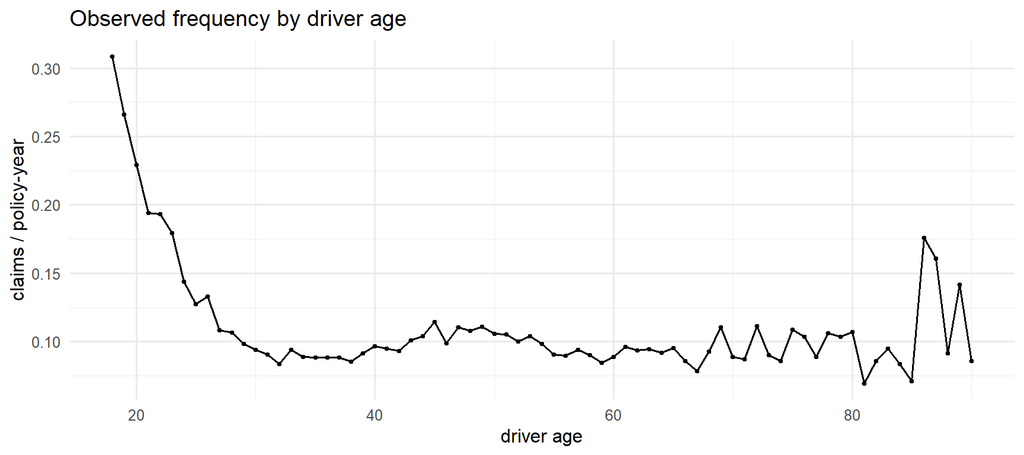

```r
p1 <- claims %>%
  group_by(DrivAge) %>%
  summarise(freq = sum(ClaimNb) / sum(Exposure), exposure = sum(Exposure)) %>%
  filter(exposure > 50) %>%
  ggplot(aes(DrivAge, freq)) +
  geom_line() + geom_point(size = 0.8) +
  labs(title = "Observed frequency by driver age", y = "claims / policy-year", x = "driver age")

p2 <- claims %>%
  group_by(BonusMalus) %>%
  summarise(freq = sum(ClaimNb) / sum(Exposure), exposure = sum(Exposure)) %>%
  filter(exposure > 50) %>%
  ggplot(aes(BonusMalus, freq)) +
  geom_line() + geom_point(size = 0.8) +
  labs(title = "Observed frequency by bonus-malus", y = "claims / policy-year", x = "bonus-malus score")

p1
```

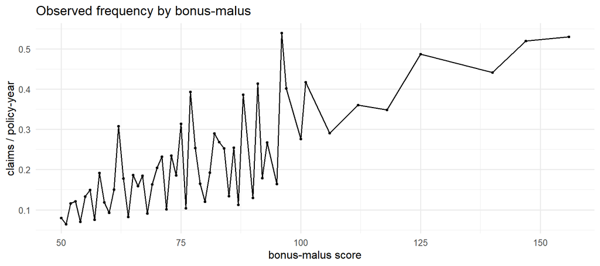

```r
p2
```

Driver age shows the well-known non-monotonic pattern (elevated frequency for young and very old drivers), which motivates **banding** age into categories for the GLM rather than assuming a linear effect on the log scale. Bonus-malus is closer to monotonic and is kept as a numeric term.

```r
claims <- claims %>%
  mutate(
    DrivAgeBand = cut(DrivAge, breaks = c(17, 21, 25, 30, 40, 50, 65, 90),
                       labels = c("18-21","22-25","26-30","31-40","41-50","51-65","66+")),
    VehAgeBand = cut(VehAge, breaks = c(-1, 0, 3, 7, 14, 40),
                      labels = c("0","1-3","4-7","8-14","15+")),
    logDensity = log(Density)
  )
```

# 3 Train/test split

An 80/20 split is used purely to sanity-check out-of-sample fit; with a single historical cross-section this is not a substitute for the temporal or geographic out-of-sample validation a production pricing model would need (see caveats in the README).

```r
set.seed(346)
n <- nrow(claims)
train_idx <- sample.int(n, size = round(0.8 * n))
train <- claims[train_idx, ]
test <- claims[-train_idx, ]
```

# 4 Poisson GLM for claim frequency

```r
form <- ClaimNb ~ Area + VehPower + VehAgeBand + DrivAgeBand + BonusMalus +
  VehBrand + VehGas + logDensity + Region

fit_pois <- glm(form, data = train, family = poisson(link = "log"),
                 offset = log(Exposure))

summary(fit_pois)$call
```

```
## glm(formula = form, family = poisson(link = "log"), data = train,
##     offset = log(Exposure))
```

```r
AIC(fit_pois)
```

```
## [1] 225651.7
```

## 4.1 Overdispersion check

```r
pearson_resid <- residuals(fit_pois, type = "pearson")
dispersion <- sum(pearson_resid^2) / fit_pois$df.residual
dispersion
```

```
## [1] 2.249646
```

A Pearson dispersion statistic above 1 indicates the variance of claim counts exceeds the Poisson assumption (`Var = mean`) — common for claims data because of unobserved heterogeneity between policyholders. This motivates a negative binomial GLM, which adds a dispersion parameter (`Var = mean + mean^2/theta`).

## 4.2 Negative binomial GLM

```r
fit_nb <- glm.nb(form, data = train, offset = log(Exposure),
                  init.theta = 1, control = glm.control(maxit = 100))

summary(fit_nb)$theta
```

```
## [1] 1.227359
```

```r
AIC(fit_pois, fit_nb)
```

```
##          df      AIC
## fit_pois 51 225651.7
## fit_nb   52 225180.4
```

## 4.3 Poisson vs negative binomial: is the extra dispersion parameter justified?

A naive likelihood-ratio test between Poisson and NB is invalid because the Poisson model sits on the *boundary* of the NB parameter space (`theta -> Inf`), so the test statistic isn’t chi-squared with the usual degrees of freedom (Self & Liang, 1987); the correct reference distribution is a 50:50 mixture of chi-squared(0) and chi-squared(1), which halves the usual chi-squared(1) p-value.

`pscl::odTest` implements this, but only by refitting its own internal Poisson comparison model from `glmobj$call$formula` — since our offset is passed as a separate `offset=` argument rather than embedded in the formula, that internal refit silently drops it, comparing a rate model against a non-rate one and producing a nonsensical (negative) test statistic. The fix is to compare our own two correctly-specified fits directly, applying the same boundary correction by hand:

```r
LR_stat <- 2 * (as.numeric(logLik(fit_nb)) - as.numeric(logLik(fit_pois)))
p_value <- 0.5 * pchisq(LR_stat, df = 1, lower.tail = FALSE)
c(LR_statistic = LR_stat, p_value = p_value)
```

```
##  LR_statistic       p_value
##  4.732416e+02 3.157462e-105
```

# 5 Model comparison: likelihood-ratio tests for nested Poisson models

Within the Poisson family, nested models can be compared with a standard deviance-based LRT. Here, dropping `Region` (kept `Area` as the coarser geographic factor) tests whether the finer regional split earns its degrees of freedom:

```r
fit_pois_noregion <- update(fit_pois, . ~ . - Region)
anova(fit_pois_noregion, fit_pois, test = "Chisq")
```

```
## Analysis of Deviance Table
##
## Model 1: ClaimNb ~ Area + VehPower + VehAgeBand + DrivAgeBand + BonusMalus +
##     VehBrand + VehGas + logDensity
## Model 2: ClaimNb ~ Area + VehPower + VehAgeBand + DrivAgeBand + BonusMalus +
##     VehBrand + VehGas + logDensity + Region
##   Resid. Df Resid. Dev Df Deviance  Pr(>Chi)
## 1    542380     170285
## 2    542359     170121 21   164.26 < 2.2e-16 ***
## ---
## Signif. codes:  0 '***' 0.001 '**' 0.01 '*' 0.05 '.' 0.1 ' ' 1
```

```r
AIC(fit_pois_noregion, fit_pois)
```

```
##                   df      AIC
## fit_pois_noregion 30 225773.9
## fit_pois          51 225651.7
```

# 6 Residual diagnostics

## 6.1 Classical residuals, leverage and influence

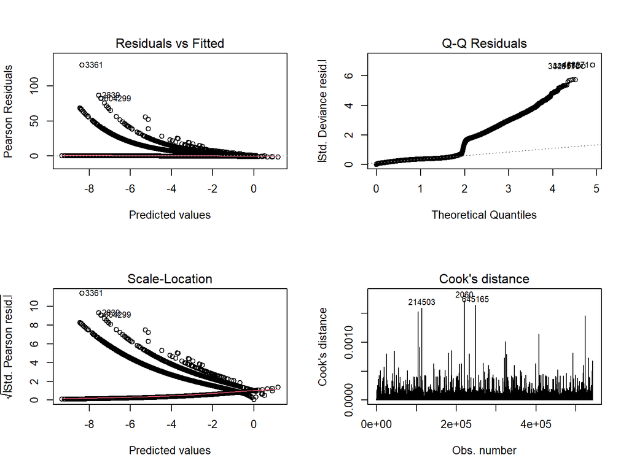

```r
par(mfrow = c(2, 2))
plot(fit_pois, which = 1:4)
```

```r
cooks_d <- cooks.distance(fit_pois)
head(sort(cooks_d, decreasing = TRUE), 10)
```

```
##         2060       645165       214503         3368       211373       632673
## 0.0017168300 0.0016419487 0.0015888191 0.0015230635 0.0014568814 0.0011362903
##       214607        34089       533969       363815
## 0.0010112185 0.0009136635 0.0008549594 0.0008493216
```

With ~540k training rows, no single policy has practically meaningful influence (all Cook’s distances are far below the usual 1 threshold), but the diagnostic is worth running as a check for data-entry errors.

## 6.2 Simulation-based residuals (DHARMa)

Deviance residuals from count GLMs are notoriously hard to read directly (they’re bounded and skewed even for a well-specified model). DHARMa instead simulates new response data from the fitted model many times and compares the observed value’s rank to the simulated distribution, giving a residual that should be uniform(0,1) under a correctly specified model — this works the same way for Poisson and negative binomial fits, which is why it’s a natural complement to the classical diagnostics above.

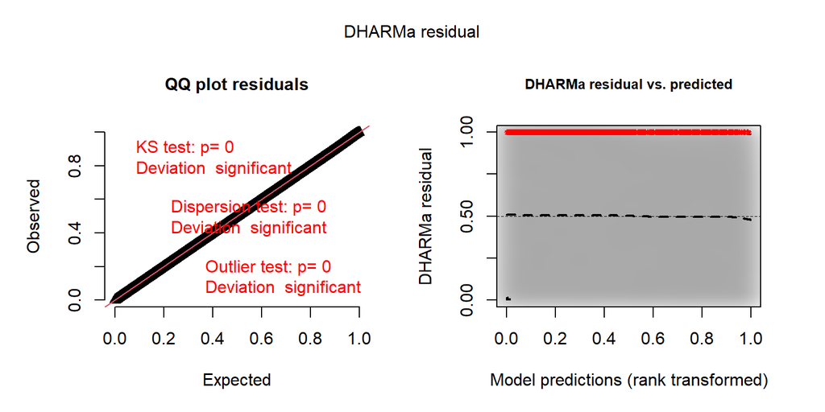

```r
sim_nb <- simulateResiduals(fit_nb, n = 250, seed = 346)
plot(sim_nb)
```

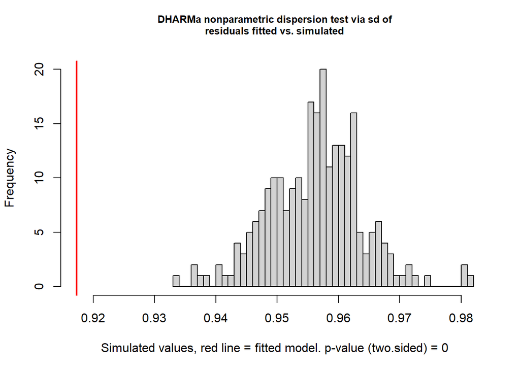

```
##
##  DHARMa nonparametric dispersion test via sd of residuals fitted vs.
##  simulated
##
## data:  simulationOutput
## dispersion = 0.95929, p-value < 2.2e-16
## alternative hypothesis: two.sided
```

```r
testDispersion(sim_nb)
```

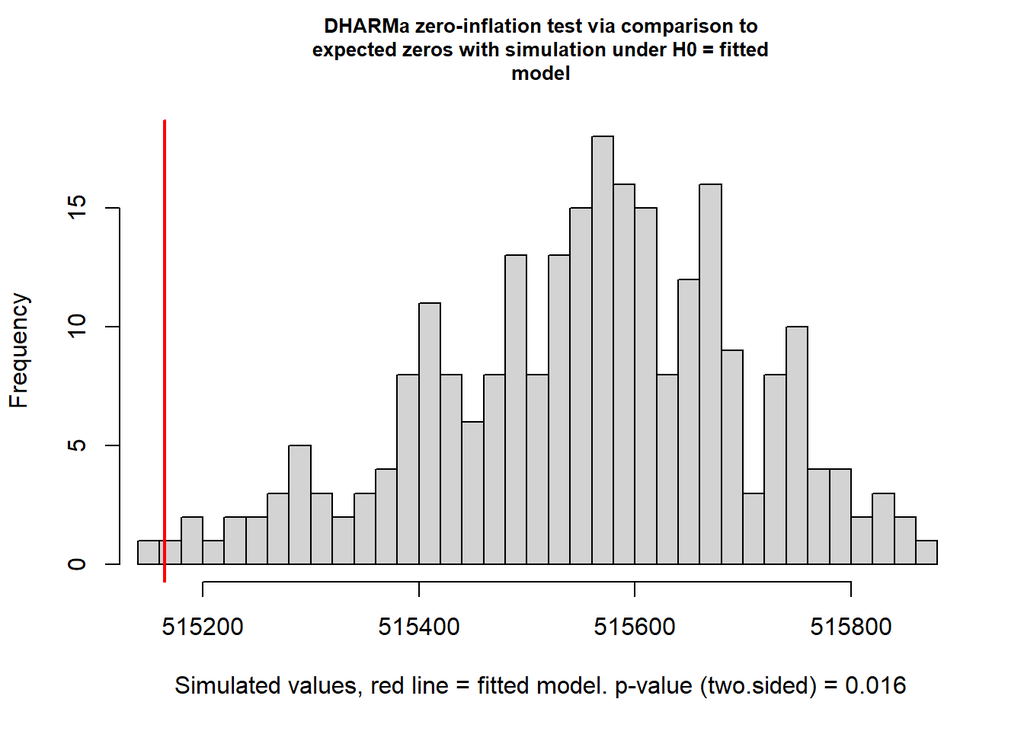

```
##
##  DHARMa zero-inflation test via comparison to expected zeros with
##  simulation under H0 = fitted model
##
## data:  simulationOutput
## ratioObsSim = 0.99924, p-value = 0.016
## alternative hypothesis: two.sided
```

```r
testZeroInflation(sim_nb)
```

# 7 Predicted rates with confidence intervals

Predicted claim frequency by bonus-malus score, holding other rating factors at their most common level, with 95% CIs from the delta method on the linear predictor (Poisson/NB GLM predictions on the log-link scale):

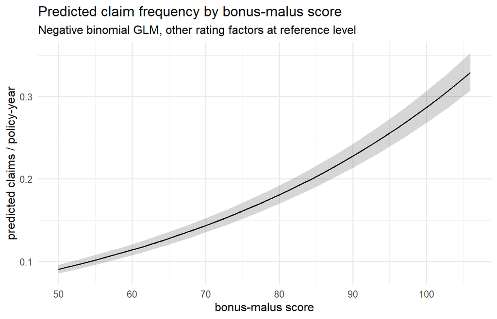

```r
reference_row <- function(data) {
  data.frame(
    Area = names(sort(table(data$Area), decreasing = TRUE))[1],
    VehPower = median(data$VehPower),
    VehAgeBand = names(sort(table(data$VehAgeBand), decreasing = TRUE))[1],
    DrivAgeBand = names(sort(table(data$DrivAgeBand), decreasing = TRUE))[1],
    VehBrand = names(sort(table(data$VehBrand), decreasing = TRUE))[1],
    VehGas = names(sort(table(data$VehGas), decreasing = TRUE))[1],
    logDensity = median(data$logDensity),
    Region = names(sort(table(data$Region), decreasing = TRUE))[1]
  )
}

bm_range <- seq(min(train$BonusMalus), quantile(train$BonusMalus, 0.99), length.out = 40)
newdata <- reference_row(train)[rep(1, length(bm_range)), ]
newdata$BonusMalus <- bm_range
newdata$Exposure <- 1  # predict a rate per full policy-year

pred_link <- predict(fit_nb, newdata = newdata, type = "link", se.fit = TRUE)
newdata <- newdata %>%
  mutate(
    fit = exp(pred_link$fit),
    lwr = exp(pred_link$fit - 1.96 * pred_link$se.fit),
    upr = exp(pred_link$fit + 1.96 * pred_link$se.fit)
  )

ggplot(newdata, aes(BonusMalus, fit)) +
  geom_ribbon(aes(ymin = lwr, ymax = upr), alpha = 0.2) +
  geom_line() +
  labs(title = "Predicted claim frequency by bonus-malus score",
       subtitle = "Negative binomial GLM, other rating factors at reference level",
       x = "bonus-malus score", y = "predicted claims / policy-year")
```

## 7.1 Rating factor relativities

Exponentiated coefficients from the negative binomial GLM, read as multiplicative adjustments to the baseline frequency (reference level = 1):

```r
# Wald CIs computed directly from the coefficient table: fast and adequate
# at this sample size. broom::tidy()'s conf.int machinery (even with
# conf.method = "Wald") is impractically slow here, since it still routes
# glm.nb objects through per-coefficient profiling internally.
coef_tab <- summary(fit_nb)$coefficients
relativities <- data.frame(
  term = rownames(coef_tab),
  estimate = exp(coef_tab[, "Estimate"]),
  conf.low = exp(coef_tab[, "Estimate"] - 1.96 * coef_tab[, "Std. Error"]),
  conf.high = exp(coef_tab[, "Estimate"] + 1.96 * coef_tab[, "Std. Error"])
) %>%
  filter(term != "(Intercept)") %>%
  arrange(desc(estimate))

head(relativities, 15)
```

```
##                        term estimate  conf.low conf.high
## RegionR94         RegionR94 1.245455 1.0735077  1.444944
## RegionR74         RegionR74 1.238864 1.0668812  1.438572
## RegionR21         RegionR21 1.132135 0.9377282  1.366845
## RegionR53         RegionR53 1.125768 1.0544308  1.201932
## VehBrandB12     VehBrandB12 1.125142 1.0802953  1.171850
## RegionR82         RegionR82 1.117631 1.0578785  1.180758
## RegionR24         RegionR24 1.108121 1.0480567  1.171628
## RegionR22         RegionR22 1.082979 0.9628855  1.218052
## VehBrandB11     VehBrandB11 1.076377 0.9847318  1.176552
## VehBrandB5       VehBrandB5 1.071823 1.0130198  1.134039
## VehGasRegular VehGasRegular 1.063287 1.0371924  1.090037
## AreaD                 AreaD 1.046727 0.9345394  1.172382
## AreaE                 AreaE 1.044612 0.8981801  1.214918
## logDensity       logDensity 1.039769 1.0104978  1.069889
## RegionR26         RegionR26 1.038733 0.9300931  1.160063
```

# 8 Out-of-sample check

```r
test$pred_nb <- predict(fit_nb, newdata = test, type = "response")
poisson_deviance <- function(y, mu) 2 * sum(ifelse(y == 0, 0, y * log(y / mu)) - (y - mu))
poisson_deviance(test$ClaimNb, test$pred_nb) / nrow(test)
```

```
## [1] 0.3147486
```

Mean out-of-sample Poisson deviance per policy for the negative binomial GLM’s point predictions on the held-out 20%.

# 9 Conclusions

See the README for what this project deliberately does not claim.